# preprocessing_census

Queenie

31/01/2021

```r
library(tidyverse)
```

```r
library(dplyr)
library(reshape2)
library(ggplot2)
library(Hmisc)
library(corrplot)
library(mice)
library(VIM)
library(pROC)
library(caret)
library(sqldf)
library(RColorBrewer)
library(viridis)
```

load data

```r
column_names <- c("age", "workclass", "fnl_wgt", "education", "education_num", "marital_status", "occupation", "relationship", "race", "sex", "capital_gain", "capital_loss", "hours_per_week", "native_country", "class")
data <- read.delim(file.choose(), sep =",", header = FALSE, na.strings = c("NA","","#NA"), col.names = column_names)
```

preview dataset:

```r
head(data,10)
```

```
##    age         workclass fnl_wgt  education education_num
## 1   39         State-gov   77516  Bachelors            13
## 2   50  Self-emp-not-inc   83311  Bachelors            13
## 3   38           Private  215646    HS-grad             9
## 4   53           Private  234721       11th             7
## 5   28           Private  338409  Bachelors            13
## 6   37           Private  284582    Masters            14
## 7   49           Private  160187        9th             5
## 8   52  Self-emp-not-inc  209642    HS-grad             9
## 9   31           Private   45781    Masters            14
## 10  42           Private  159449  Bachelors            13
##            marital_status         occupation   relationship   race     sex
## 1           Never-married       Adm-clerical  Not-in-family  White    Male
## 2      Married-civ-spouse    Exec-managerial        Husband  White    Male
## 3                Divorced  Handlers-cleaners  Not-in-family  White    Male
```

[output cut: 18 more lines]

```r
str(data)
```

```
## 'data.frame':    32561 obs. of  15 variables:
##  $ age           : int  39 50 38 53 28 37 49 52 31 42 ...
##  $ workclass     : chr  " State-gov" " Self-emp-not-inc" " Private" " Private" ...
##  $ fnl_wgt       : int  77516 83311 215646 234721 338409 284582 160187 209642 45781 159449 ...
##  $ education     : chr  " Bachelors" " Bachelors" " HS-grad" " 11th" ...
##  $ education_num : int  13 13 9 7 13 14 5 9 14 13 ...
##  $ marital_status: chr  " Never-married" " Married-civ-spouse" " Divorced" " Married-civ-spouse" ...
##  $ occupation    : chr  " Adm-clerical" " Exec-managerial" " Handlers-cleaners" " Handlers-cleaners" ...
##  $ relationship  : chr  " Not-in-family" " Husband" " Not-in-family" " Husband" ...
##  $ race          : chr  " White" " White" " White" " Black" ...
##  $ sex           : chr  " Male" " Male" " Male" " Male" ...
##  $ capital_gain  : int  2174 0 0 0 0 0 0 0 14084 5178 ...
##  $ capital_loss  : int  0 0 0 0 0 0 0 0 0 0 ...
##  $ hours_per_week: int  40 13 40 40 40 40 16 45 50 40 ...
##  $ native_country: chr  " United-States" " United-States" " United-States" " United-States" ...
##  $ class         : chr  " <=50K" " <=50K" " <=50K" " <=50K" ...
```

```r
summary(data)
```

```
##       age         workclass            fnl_wgt         education
##  Min.   :17.00   Length:32561       Min.   :  12285   Length:32561
##  1st Qu.:28.00   Class :character   1st Qu.: 117827   Class :character
##  Median :37.00   Mode  :character   Median : 178356   Mode  :character
##  Mean   :38.58                      Mean   : 189778
##  3rd Qu.:48.00                      3rd Qu.: 237051
##  Max.   :90.00                      Max.   :1484705
##  education_num   marital_status      occupation        relationship
##  Min.   : 1.00   Length:32561       Length:32561       Length:32561
##  1st Qu.: 9.00   Class :character   Class :character   Class :character
##  Median :10.00   Mode  :character   Mode  :character   Mode  :character
##  Mean   :10.08
##  3rd Qu.:12.00
##  Max.   :16.00
##      race               sex             capital_gain    capital_loss
##  Length:32561       Length:32561       Min.   :    0   Min.   :   0.0
##  Class :character   Class :character   1st Qu.:    0   1st Qu.:   0.0
##  Mode  :character   Mode  :character   Median :    0   Median :   0.0
##                                        Mean   : 1078   Mean   :  87.3
##                                        3rd Qu.:    0   3rd Qu.:   0.0
##                                        Max.   :99999   Max.   :4356.0
##  hours_per_week  native_country        class
##  Min.   : 1.00   Length:32561       Length:32561
##  1st Qu.:40.00   Class :character   Class :character
##  Median :40.00   Mode  :character   Mode  :character
##  Mean   :40.44
##  3rd Qu.:45.00
##  Max.   :99.00
```

check distribution of target variable which is class:

```r
table(data$class)
```

```
##
##  <=50K   >50K
##  24720   7841
```

look at target variable class:

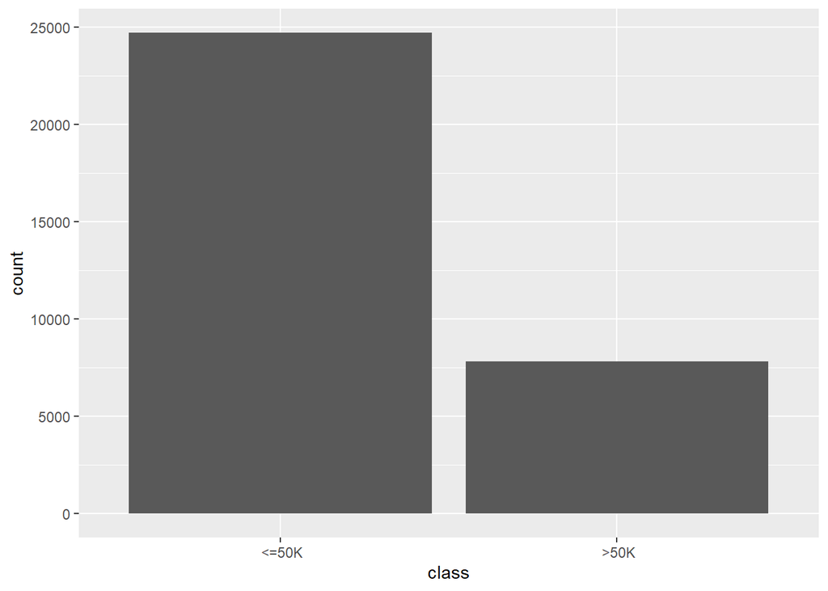

```r
ggplot(data = data) +
  geom_bar(mapping = aes(x = class))
```

testing for missing values:

```r
sapply(data, function(x) sum(is.na (x)))
```

```
##            age      workclass        fnl_wgt      education  education_num
##              0              0              0              0              0
## marital_status     occupation   relationship           race            sex
##              0              0              0              0              0
##   capital_gain   capital_loss hours_per_week native_country          class
##              0              0              0              0              0
```

to get the numeric columns only:

```r
list_of_numcols = sapply(data, is.numeric)
numcols = data[ , list_of_numcols]

str(data)
```

```
## 'data.frame':    32561 obs. of  15 variables:
##  $ age           : int  39 50 38 53 28 37 49 52 31 42 ...
##  $ workclass     : chr  " State-gov" " Self-emp-not-inc" " Private" " Private" ...
##  $ fnl_wgt       : int  77516 83311 215646 234721 338409 284582 160187 209642 45781 159449 ...
##  $ education     : chr  " Bachelors" " Bachelors" " HS-grad" " 11th" ...
##  $ education_num : int  13 13 9 7 13 14 5 9 14 13 ...
##  $ marital_status: chr  " Never-married" " Married-civ-spouse" " Divorced" " Married-civ-spouse" ...
##  $ occupation    : chr  " Adm-clerical" " Exec-managerial" " Handlers-cleaners" " Handlers-cleaners" ...
##  $ relationship  : chr  " Not-in-family" " Husband" " Not-in-family" " Husband" ...
##  $ race          : chr  " White" " White" " White" " Black" ...
##  $ sex           : chr  " Male" " Male" " Male" " Male" ...
##  $ capital_gain  : int  2174 0 0 0 0 0 0 0 14084 5178 ...
##  $ capital_loss  : int  0 0 0 0 0 0 0 0 0 0 ...
##  $ hours_per_week: int  40 13 40 40 40 40 16 45 50 40 ...
##  $ native_country: chr  " United-States" " United-States" " United-States" " United-States" ...
##  $ class         : chr  " <=50K" " <=50K" " <=50K" " <=50K" ...
```

```r
str(numcols)
```

```
## 'data.frame':    32561 obs. of  6 variables:
##  $ age           : int  39 50 38 53 28 37 49 52 31 42 ...
##  $ fnl_wgt       : int  77516 83311 215646 234721 338409 284582 160187 209642 45781 159449 ...
##  $ education_num : int  13 13 9 7 13 14 5 9 14 13 ...
##  $ capital_gain  : int  2174 0 0 0 0 0 0 0 14084 5178 ...
##  $ capital_loss  : int  0 0 0 0 0 0 0 0 0 0 ...
##  $ hours_per_week: int  40 13 40 40 40 40 16 45 50 40 ...
```

histograms for numeric variables:

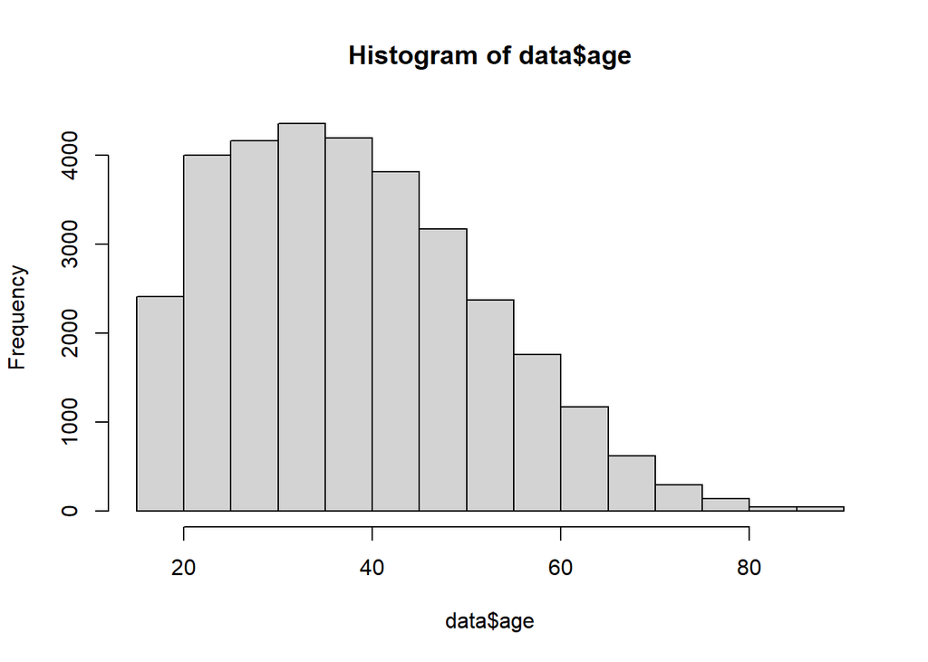

```r
hist(data$age)
```

looking at categorical variables:

```r
attach(data)
freq_tbl=table(sex)
head(freq_tbl)
```

```
## sex
##  Female    Male
##   10771   21790
```

to get proportion, input frequency table:

```r
prop.table(freq_tbl)
```

```
## sex
##    Female      Male
## 0.3307945 0.6692055
```

looking at education:

```r
freq_tbl_education= table(education)
head(freq_tbl_education)
```

```
## education
##     10th     11th     12th  1st-4th  5th-6th  7th-8th
##      933     1175      433      168      333      646
```

```r
prop.table(freq_tbl_education)
```

```
## education
##          10th          11th          12th       1st-4th       5th-6th
##   0.028653911   0.036086115   0.013298117   0.005159547   0.010226959
##       7th-8th           9th    Assoc-acdm     Assoc-voc     Bachelors
##   0.019839686   0.015785756   0.032769264   0.042443414   0.164460551
##     Doctorate       HS-grad       Masters     Preschool   Prof-school
##   0.012683886   0.322502380   0.052916065   0.001566291   0.017689874
##  Some-college
##   0.223918184
```

look at target variable class with respect to education:

```r
freq_xtab=xtabs(~education+class)
head(freq_xtab)
```

```
##           class
## education   <=50K  >50K
##    10th       871    62
##    11th      1115    60
##    12th       400    33
##    1st-4th    162     6
##    5th-6th    317    16
##    7th-8th    606    40
```

cross-tab for 2 categorical features, this time with proportions:

```r
prop.table(freq_xtab)
```

```
##                class
## education              <=50K         >50K
##    10th         0.0267497927 0.0019041184
##    11th         0.0342434200 0.0018426952
##    12th         0.0122846350 0.0010134824
##    1st-4th      0.0049752772 0.0001842695
##    5th-6th      0.0097355732 0.0004913854
##    7th-8th      0.0186112220 0.0012284635
##    9th          0.0149565431 0.0008292129
##    Assoc-acdm   0.0246306932 0.0081385707
##    Assoc-voc    0.0313565308 0.0110868831
##    Bachelors    0.0962501152 0.0682104358
##    Doctorate    0.0032861399 0.0093977458
##    HS-grad      0.2710604711 0.0514419090
##    Masters      0.0234636528 0.0294524124
##    Preschool    0.0015662910 0.0000000000
##    Prof-school  0.0046988729 0.0129910015
##    Some-college 0.1813212125 0.0425969718
```

use DPLYR to see the relationship between education and education_num:

```r
class_by_education =
  data %>%
  group_by(education) %>%
  summarise(education_num = mean(education_num, na.rm = TRUE))
```

creating a mosaic plot (plot of proportions)

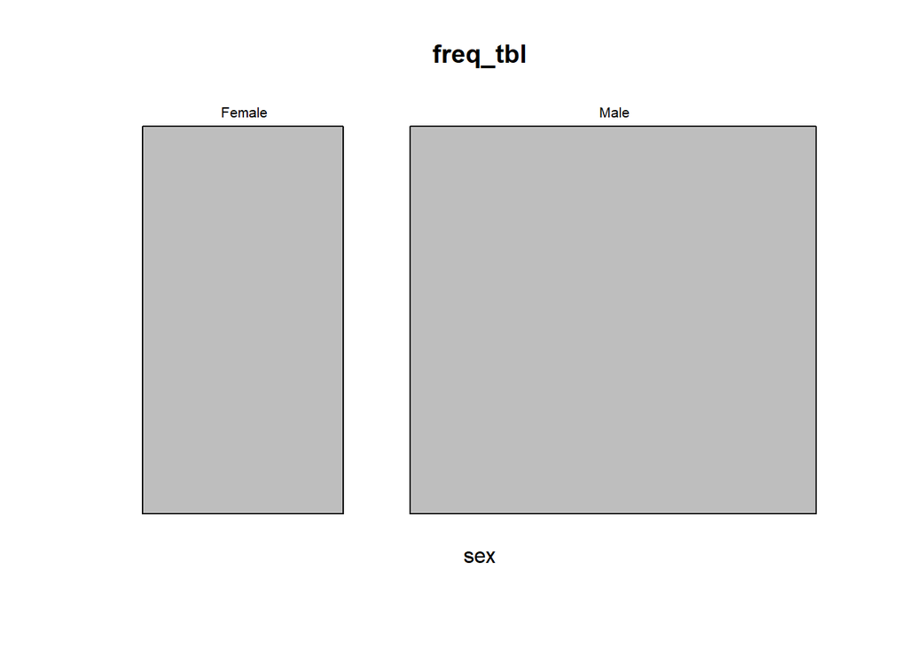

```r
mosaicplot(freq_tbl)
```

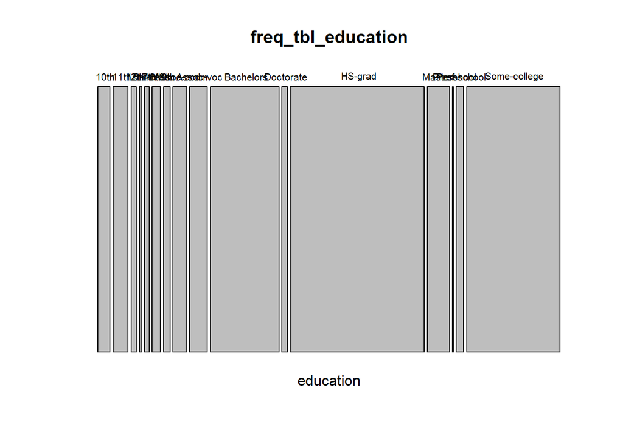

```r
mosaicplot(freq_tbl_education)
```

looking at categorical variables

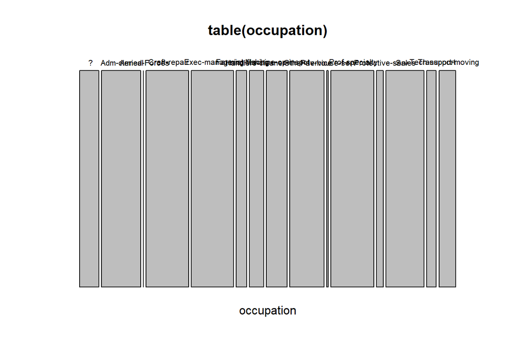

```r
mosaicplot(table(occupation))
```

Stacked bar-plot - i.e. plotting it x-tab

```r
freq_xtab=xtabs(~occupation+class)
head(freq_xtab)
```

```
##                   class
## occupation          <=50K  >50K
##    ?                 1652   191
##    Adm-clerical      3263   507
##    Armed-Forces         8     1
##    Craft-repair      3170   929
##    Exec-managerial   2098  1968
##    Farming-fishing    879   115
```

basic bar-plot will automatically be stacked if we give it the x-tab table as an input barplot of occupation vs class:

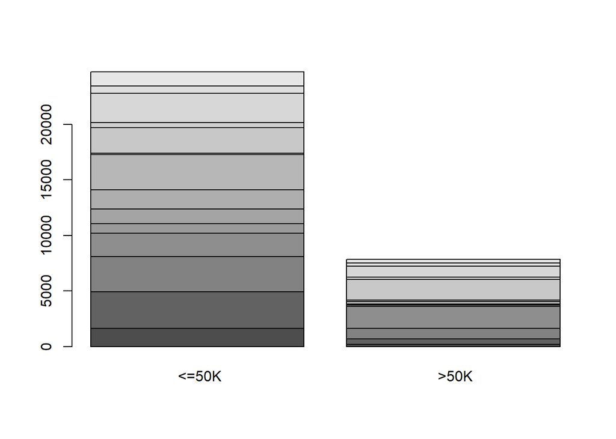

```r
barplot(freq_xtab)
```

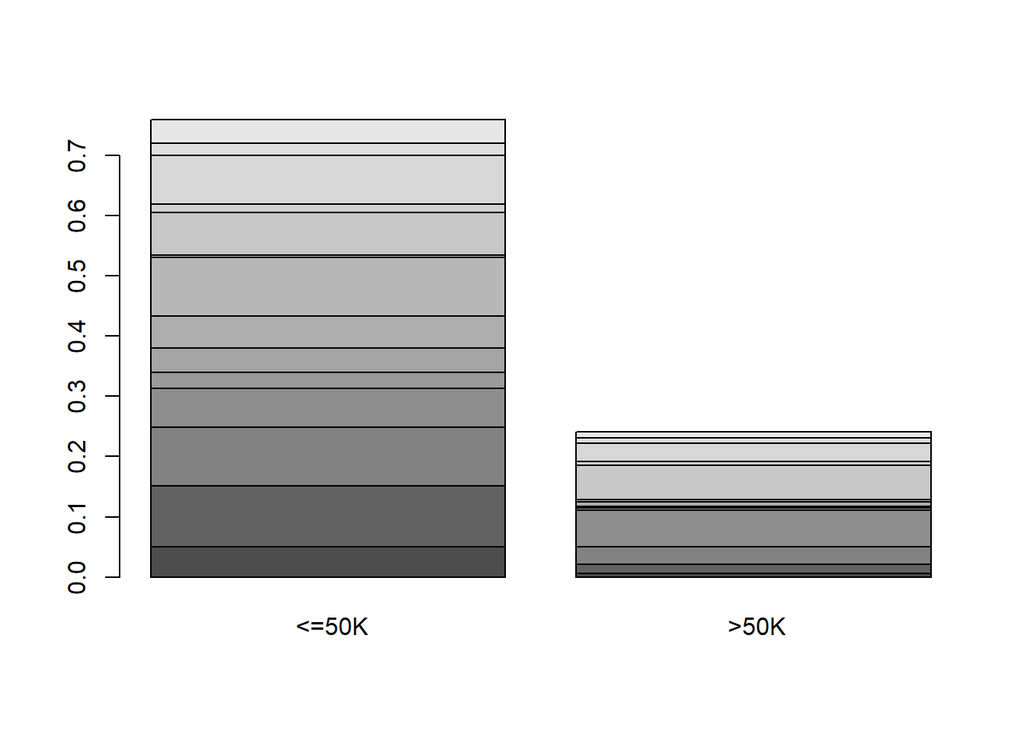

```r
barplot(prop.table(freq_xtab))
```

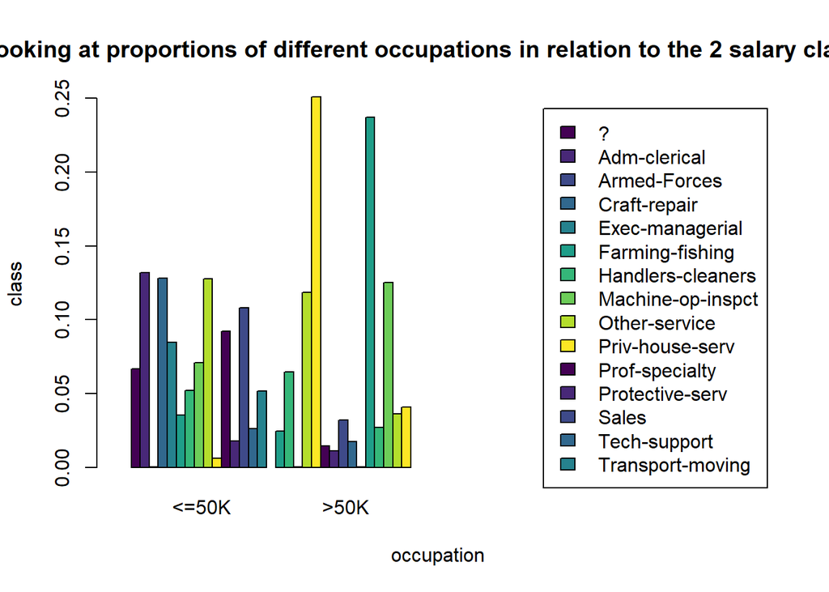

```r
barplot(prop.table(freq_xtab,2),
        legend=rownames(freq_xtab),  beside = TRUE,
        ylab = "class", xlab = "occupation",
        main = "looking at proportions of different occupations in relation to the 2 salary classes",
       xlim = c(0,70),
       col = viridis(10))
```

look at workclass versus class (2 categorical variables)

```r
workclass_vs_class_freq_xtab=xtabs(~workclass+class)
head(workclass_vs_class_freq_xtab)
```

```
##                class
## workclass        <=50K  >50K
##    ?              1645   191
##    Federal-gov     589   371
##    Local-gov      1476   617
##    Never-worked      7     0
##    Private       17733  4963
##    Self-emp-inc    494   622
```

plotting workclass vs class:

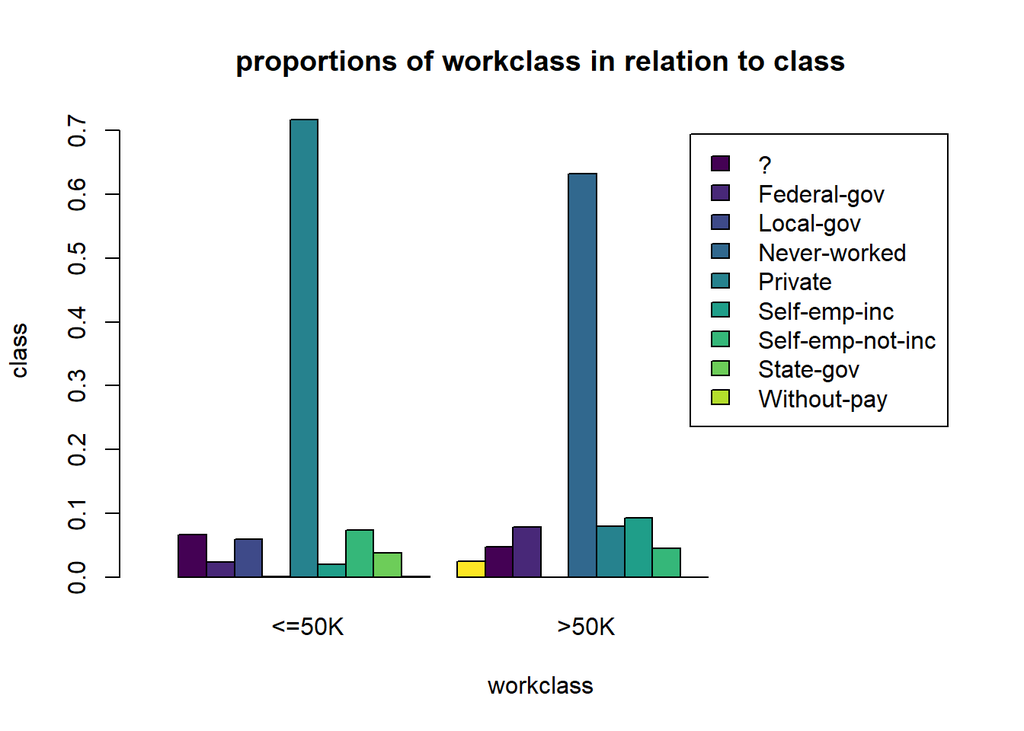

```r
workclass_vs_class_freq_xtab = table(workclass, class) #create a simple frequency table of workclass vs class
workclass_vs_class_pct_xtab = prop.table(workclass_vs_class_freq_xtab, 2)  #turn into a proportion table
barplot(workclass_vs_class_pct_xtab,
        legend=rownames(workclass_vs_class_pct_xtab), beside = TRUE,
        ylab = "class", xlab = "workclass",
        main = "proportions of workclass in relation to class",
        xlim = c(0, 28),
        col = viridis(10))
```

plotting marital status vs class:

```r
marital_status_vs_class_freq_xtab=xtabs(~marital_status+class)
head(marital_status_vs_class_freq_xtab)
```

```
##                         class
## marital_status            <=50K  >50K
##    Divorced                3980   463
##    Married-AF-spouse         13    10
##    Married-civ-spouse      8284  6692
##    Married-spouse-absent    384    34
##    Never-married          10192   491
##    Separated                959    66
```

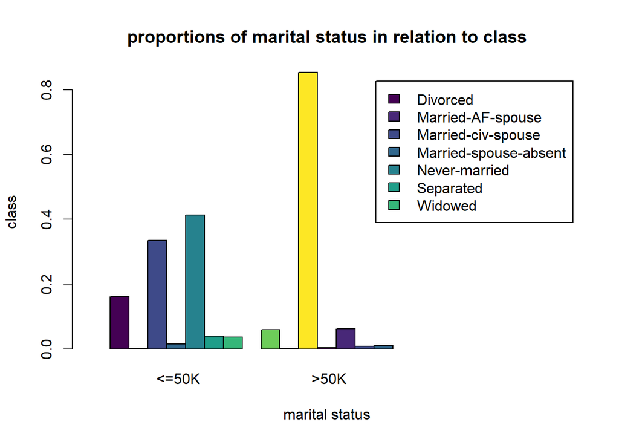

```r
marital_status_vs_class_freq_xtab = table(marital_status,class)
marital_status_vs_class_pct_xtab = prop.table(marital_status_vs_class_freq_xtab,2)
barplot(marital_status_vs_class_pct_xtab,
        legend= rownames(marital_status_vs_class_pct_xtab), beside = TRUE,
        ylab = "class", xlab = "marital status",
        main = "proportions of marital status in relation to class",
        xlim = c(0, 25),   #this is used to move legend to the right
        col = viridis(10))
```

plotting education vs class

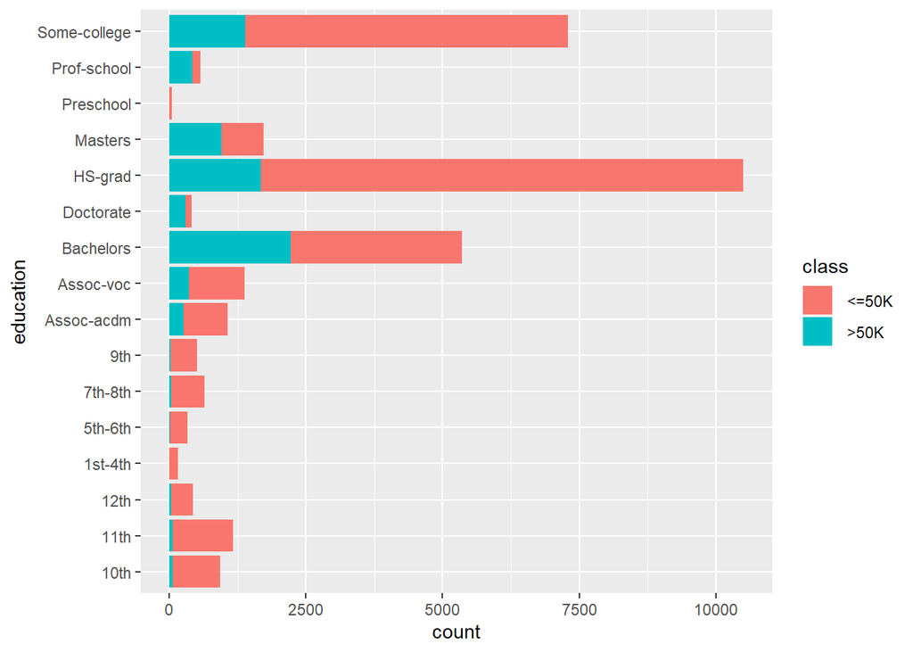

```r
ggplot(data = data, aes(y = education, fill = class)) +
  geom_bar(position = "stack")   #different bars stacked together
```

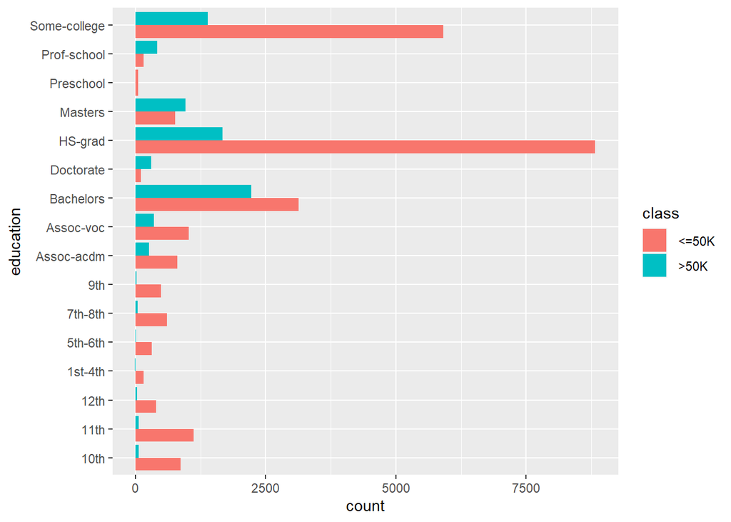

```r
ggplot(data = data, aes(y = education, fill = class)) +
  geom_bar(position = "dodge")   #different bars side by side
```

plotting native country vs. class

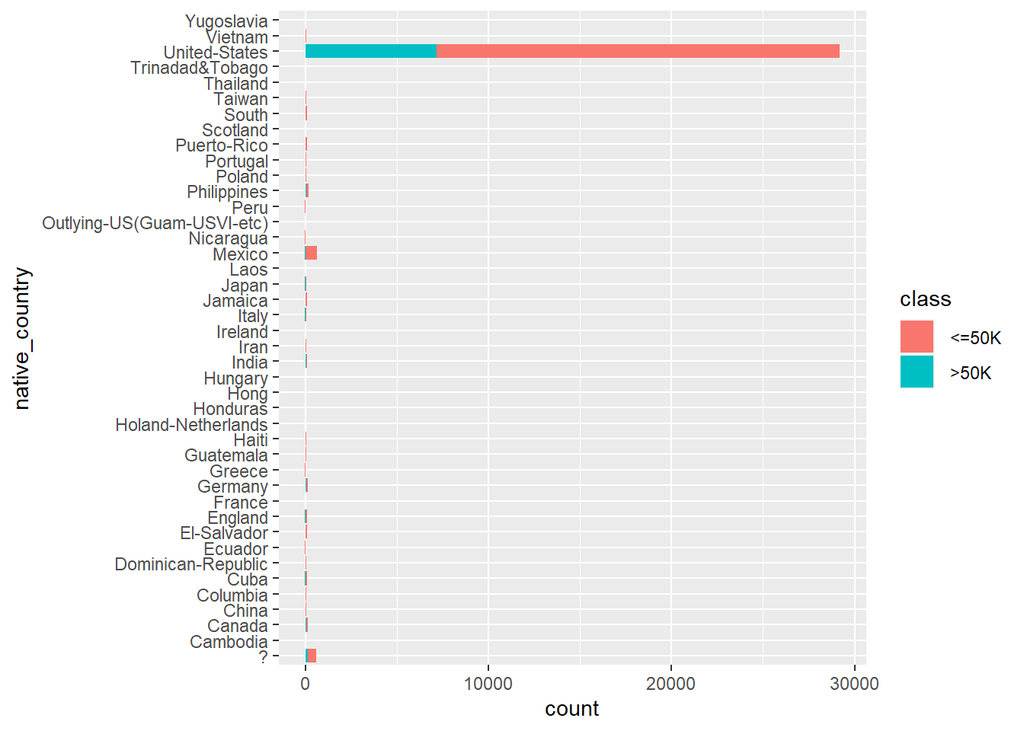

```r
ggplot(data = data, aes(y = native_country, fill = class))+
  geom_bar(position = "stack")
```

plotting occupation vs class

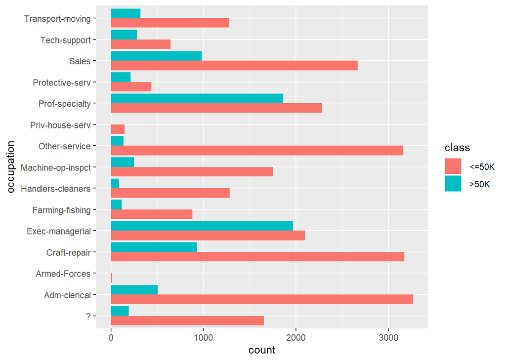

```r
ggplot(data = data, aes(y = occupation, fill = class))+
  geom_bar(position = "dodge")
```

check missing values for each column in dataset:

```r
colSums(is.na(data))
```

```
##            age      workclass        fnl_wgt      education  education_num
##              0              0              0              0              0
## marital_status     occupation   relationship           race            sex
##              0              0              0              0              0
##   capital_gain   capital_loss hours_per_week native_country          class
##              0              0              0              0              0
```

missing values are represented by “?” in the dataset

convert ? values to NA in dataset and save into new dataframe:

```r
data_NA <- as.data.frame(data %>%
  mutate_if(is.character, list(~na_if(., " ?"))))

View(data_NA)
```

total missing NA values:

```r
sum(is.na(data_NA))
```

```
## [1] 4262
```

compute the total missing values in each column:

```r
colSums(is.na(data_NA))
```

```
##            age      workclass        fnl_wgt      education  education_num
##              0           1836              0              0              0
## marital_status     occupation   relationship           race            sex
##              0           1843              0              0              0
##   capital_gain   capital_loss hours_per_week native_country          class
##              0              0              0            583              0
```

missing values

getting the percentage of missing values:

```r
percent_missing = function(x){sum(is.na(x))/length(x)*100}
apply(data_NA,2,percent_missing)
```

```
##            age      workclass        fnl_wgt      education  education_num
##       0.000000       5.638647       0.000000       0.000000       0.000000
## marital_status     occupation   relationship           race            sex
##       0.000000       5.660146       0.000000       0.000000       0.000000
##   capital_gain   capital_loss hours_per_week native_country          class
##       0.000000       0.000000       0.000000       1.790486       0.000000
```

visualizing missing values: install.packages(“mice”)

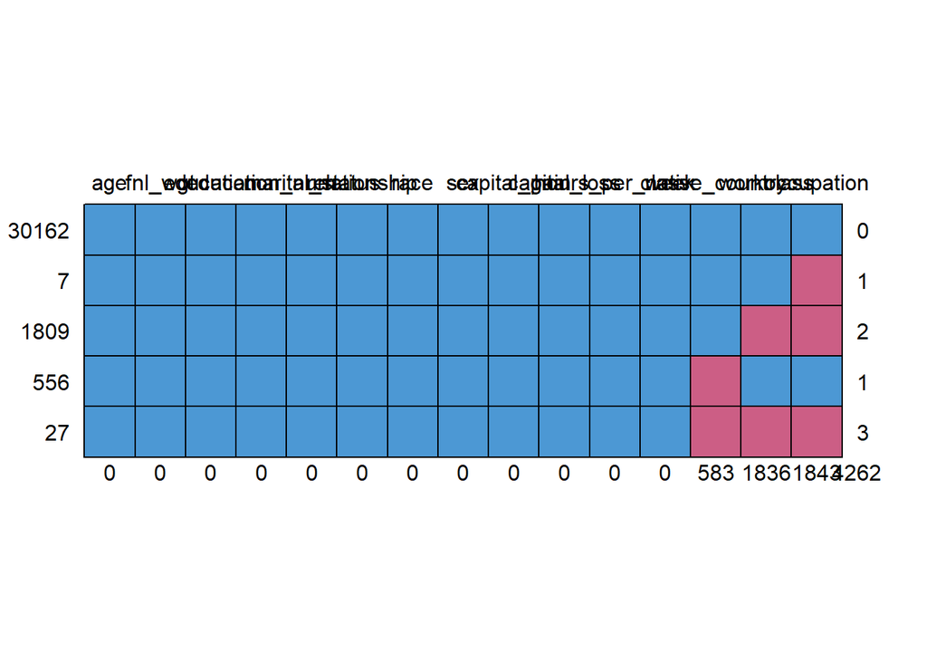

```
##       age fnl_wgt education education_num marital_status relationship race sex
## 30162   1       1         1             1              1            1    1   1
## 7       1       1         1             1              1            1    1   1
## 1809    1       1         1             1              1            1    1   1
## 556     1       1         1             1              1            1    1   1
## 27      1       1         1             1              1            1    1   1
##         0       0         0             0              0            0    0   0
##       capital_gain capital_loss hours_per_week class native_country workclass
## 30162            1            1              1     1              1         1
## 7                1            1              1     1              1         1
## 1809             1            1              1     1              1         0
## 556              1            1              1     1              0         1
## 27               1            1              1     1              0         0
##                  0            0              0     0            583      1836
##       occupation
## 30162          1    0
## 7              0    1
## 1809           0    2
## 556            1    1
## 27             0    3
##             1843 4262
```

```r
library(mice)

md.pattern(data_NA)
```